# Praktikum 2 Anreg

# 1 Data

## 1.1 Membaca Data

```r
library(readxl)
data <- read_excel("C:\\Users\\ASUS\\OneDrive\\Desktop\\SEM 4\\ANREG\\NSC-2025.xlsx", sheet="Sheet2")
head(data) #menampilkan sebagian data awal
```

| Kabupaten/Kota | Indeks Pembangunan Manusia | Rata-Rata Lama Sekolah | PDRB ADHK (MILYAR RUPIAH) | Persentase Penduduk Miskin | Persentase Akses Sanitasi Layak | Kontribusi Sektor Industri Pengolahan teradap PDRB/PDB (%) | Pertumbuhan Ekonomi Sektor Industri Pengolahan | Indeks Pembangunan Gender | Tingkat Partisipasi Angkatan Kerja (TPAK) | Tingkat Pengangguran Terbuka (TPT) |
| --- | --- | --- | --- | --- | --- | --- | --- | --- | --- | --- |
| Kepulauan Seribu | 76.69 | 9.26 | 3268.5 | 13.03 | 89.10 | 4.06 | 0.37 | 93.62 | 72.58 | 7.93 |
| Kota Jakarta Selatan | 87.57 | 11.95 | 500422.7 | 3.03 | 92.61 | 1.38 | 3.74 | 97.30 | 64.81 | 5.22 |
| Kota Jakarta Timur | 84.76 | 11.99 | 362068.1 | 4.09 | 97.15 | 26.73 | 2.13 | 95.90 | 64.49 | 6.95 |
| Kota Jakarta Pusat | 83.75 | 11.61 | 532606.9 | 4.63 | 90.30 | 0.84 | 0.01 | 96.24 | 65.12 | 6.24 |
| Kota Jakarta Barat | 84.40 | 11.24 | 383113.1 | 3.94 | 94.94 | 5.30 | 2.16 | 95.66 | 64.12 | 6.18 |
| Kota Jakarta Utara | 82.13 | 10.85 | 380461.1 | 6.44 | 91.39 | 30.31 | 0.52 | 94.43 | 67.77 | 6.18 |

## 1.2 Menyesuaikan Peubah

```r
colnames(data) <- c("Kabupaten/Kota", "Y", paste0("X", 1:9))
head(data)
```

| Kabupaten/Kota | Y | X1 | X2 | X3 | X4 | X5 | X6 | X7 | X8 | X9 |
| --- | --- | --- | --- | --- | --- | --- | --- | --- | --- | --- |
| Kepulauan Seribu | 76.69 | 9.26 | 3268.5 | 13.03 | 89.10 | 4.06 | 0.37 | 93.62 | 72.58 | 7.93 |
| Kota Jakarta Selatan | 87.57 | 11.95 | 500422.7 | 3.03 | 92.61 | 1.38 | 3.74 | 97.30 | 64.81 | 5.22 |
| Kota Jakarta Timur | 84.76 | 11.99 | 362068.1 | 4.09 | 97.15 | 26.73 | 2.13 | 95.90 | 64.49 | 6.95 |
| Kota Jakarta Pusat | 83.75 | 11.61 | 532606.9 | 4.63 | 90.30 | 0.84 | 0.01 | 96.24 | 65.12 | 6.24 |
| Kota Jakarta Barat | 84.40 | 11.24 | 383113.1 | 3.94 | 94.94 | 5.30 | 2.16 | 95.66 | 64.12 | 6.18 |
| Kota Jakarta Utara | 82.13 | 10.85 | 380461.1 | 6.44 | 91.39 | 30.31 | 0.52 | 94.43 | 67.77 | 6.18 |

# 2 Eksplorasi Data

```r
n <- nrow(data)
```

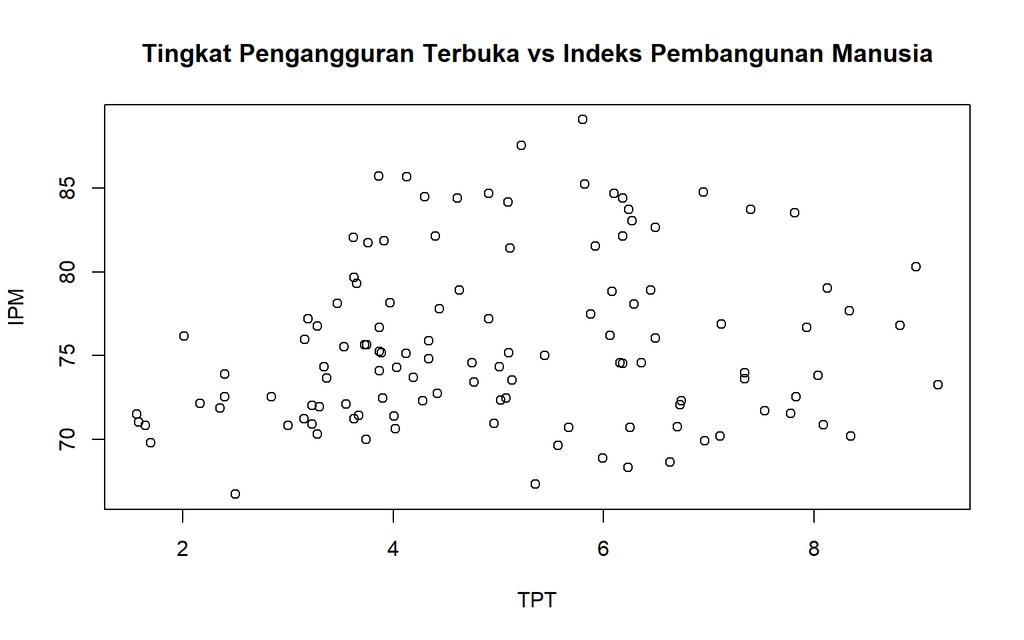

```r
plot(data$X9, data$Y,
     main = "Tingkat Pengangguran Terbuka vs Indeks Pembangunan Manusia",
     xlab = "TPT",
     ylab = "IPM")
```

```r
summary(data$Y)
```

```
##    Min. 1st Qu.  Median    Mean 3rd Qu.    Max.
##   66.72   71.91   74.57   75.75   78.86   89.10
```

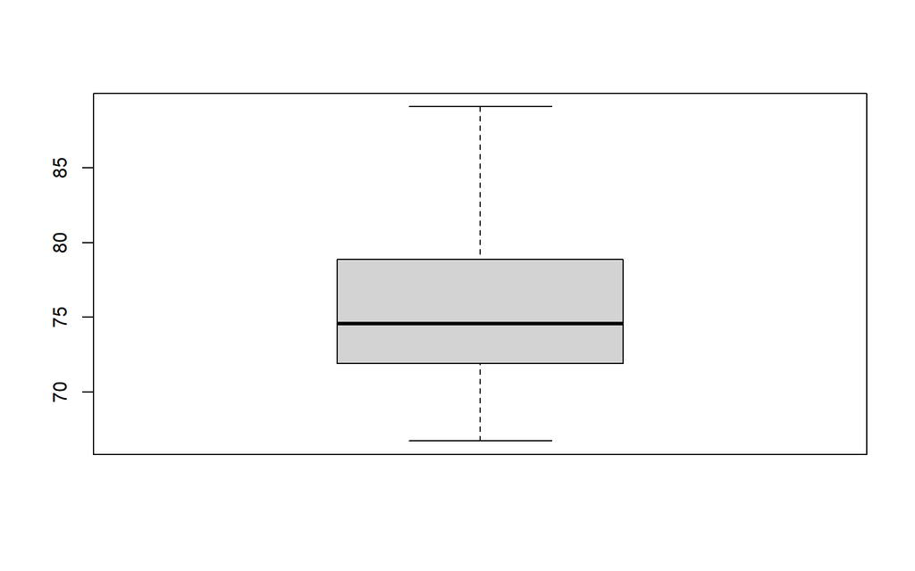

```r
boxplot(data$Y)
```

```r
summary(data$X9)
```

```
##    Min. 1st Qu.  Median    Mean 3rd Qu.    Max.
##   1.560   3.700   4.910   5.026   6.260   9.180
```

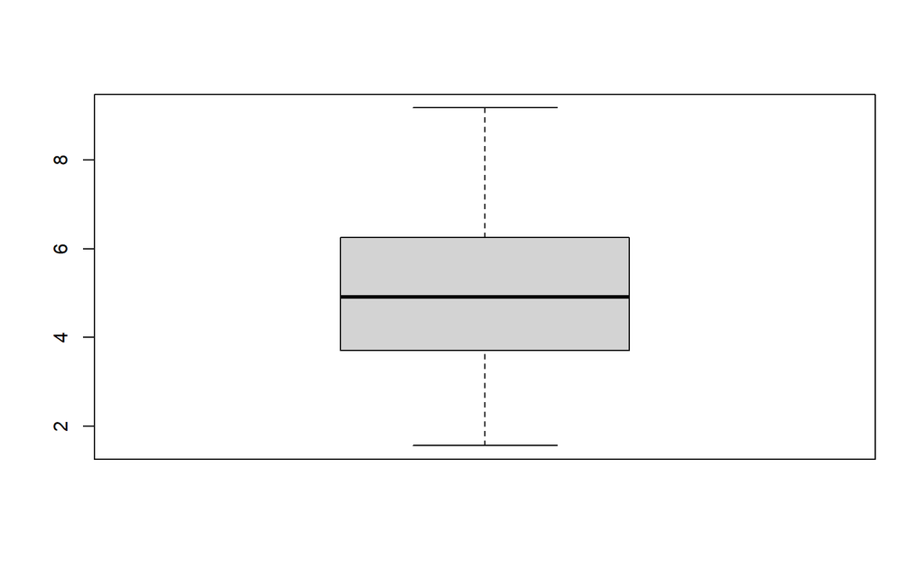

```r
boxplot(data$X9)
```

# 3 Pembentukan Model

## 3.1 Model Manual

### 3.1.1 Koefisien Regresi

```r
x <- data$X9
y <- data$Y
```

```r
b1 <- (sum(x*y)-(sum(x)*sum(y)/n))/(sum(x^2)-(sum(x)^2/n))
b0 <- mean(y)-b1*mean(x)

cat("Koefisien b0:", b0, "\n")
```

```
## Koefisien b0: 73.49741
```

```r
cat("Koefisien b1:", b1, "\n")
```

```
## Koefisien b1: 0.4473984
```

### 3.1.2 Standar Error Parameter Regresi

Standar error menunjukan seberapa besar ketidakpastian dalam estimasi koefisien

```r
galat <- y-(b0+b1*x)
ragam_galat <- sum(galat^2)/(n-2)

se_b0 <- sqrt(ragam_galat*(1/n+mean(x)^2/sum((x-mean(x))^2)))
se_b1 <- sqrt(ragam_galat/sum((x-mean(x))^2))

cat("Standar error b0:", se_b0, "\n")
```

```
## Standar error b0: 1.357898
```

```r
cat("Standar error b1:", se_b1, "\n")
```

```
## Standar error b1: 0.2544849
```

### 3.1.3 Signifikansi Parameter (nilai-t)

Nilai ini menunjukkan tingkat signifikansi secara parsial dari setiap koefisien peubah berdasarkan nilai t dan probabilitas nilai p

```r
t_b0 <- b0/se_b0
t_b1 <- b1/se_b1
p_b0 <- 2*pt(-abs(t_b0 ),df<-n-2)
p_b1 <- 2*pt(-abs(t_b1 ),df<-n-2)

cat("Nilai t pada b0 adalah", t_b0, "dengan nilai p sebesar", p_b0, "\n")
```

```
## Nilai t pada b0 adalah 54.12587 dengan nilai p sebesar 1.150449e-84
```

```r
cat("Nilai t pada b1 adalah", t_b1, "dengan nilai p sebesar", p_b1, "\n")
```

```
## Nilai t pada b1 adalah 1.758055 dengan nilai p sebesar 0.08135316
```

Nilai p kurang dari alpha 0.05 untuk b0 akan tetapi tidak pada b1, sehingga b1 tidak signifikan secara parsial pada taraf nyata 5%.

### 3.1.4 Koefisien Determinasi dan Penyesuaiannya

Pada analisis regresi linier sederhana, koefisien determinasi yang digunakan adalah multiple R Squared, sedangkan regresi linier berganda menggunakan adjusted R Squared yang disesuaikan dengan banyaknya peubah

```r
r <- (sum(x*y)-sum(x)*sum(y)/n)/
  sqrt((sum(x^2)-(sum(x)^2/n))*(sum(y^2)-(sum(y)^2/n)))
Koef_det <- r^2
Koef_det
```

```
## [1] 0.02573685
```

```r
Adj_R2 <- 1-((1-Koef_det)*(n-1)/(n-1-1))
Adj_R2
```

```
## [1] 0.01740982
```

### 3.1.5 Signifikansi Simultan (F)

Nilai ini menunjukkan signifikansi dan kebaikan model secara simultan (bersamaan seluruh peubah) yang menjelaskan model secara keseluruhan memiliki hubungan berarti antara X dan Y

```r
galat<-y-(b0+b1*x)

JKG <- sum((y - (b0+b1*x))^2)
JKReg <- sum(((b0+b1*x)- mean(y))^2)
JKT <- sum((y - mean(y))^2)
JKT <- JKReg+JKG

dbReg <- 1
dbg <- n-2
dbt <- n-1

(Fhit <- (JKReg/dbReg)/(JKG/dbg))
```

```
## [1] 3.090758
```

```r
(p_Fhit <- 1-pf(Fhit, dbReg, dbg, lower.tail = F))
```

```
## [1] 0.9186468
```

Nilai p lebih dari alpha 0.05 sehingga secara simultan model tidak signifikan pada taraf nyata 5% dan model tidak dapat digunakan untuk memprediksi Y dari X9.

## 3.2 Menggunakan Fungsi `lm()`

Dalam penggunaan fungsi `lm()`, kita akan memperoleh secara langsung nilai-nilai pada pemodelan regresi dari data yang kita miliki. Hanya dengan mengeluarkan summary dan anova dari model yang terbentuk maka dapat diperoleh nilai parameter, signifikansinya, standar eror, koefisien determinasi hingga ukuran keragamannya.

```r
model <- lm(Y~X9, data = data)
summary(model)
```

```
##
## Call:
## lm(formula = Y ~ X9, data = data)
##
## Residuals:
##     Min      1Q  Median      3Q     Max
## -8.5610 -3.5350 -0.9213  2.7009 13.0077
##
## Coefficients:
##             Estimate Std. Error t value Pr(>|t|)
## (Intercept)  73.4974     1.3579  54.126   <2e-16 ***
## X9            0.4474     0.2545   1.758   0.0814 .
## ---
## Signif. codes:  0 '***' 0.001 '**' 0.01 '*' 0.05 '.' 0.1 ' ' 1
##
## Residual standard error: 4.973 on 117 degrees of freedom
## Multiple R-squared:  0.02574,    Adjusted R-squared:  0.01741
## F-statistic: 3.091 on 1 and 117 DF,  p-value: 0.08135
```

```r
anova(model)
```

|  | Df | Sum Sq | Mean Sq | F value | Pr(>F) |
| --- | --- | --- | --- | --- | --- |
| X9 | 1 | 76.4287 | 76.42870 | 3.090758 | 0.08135316 |
| Residuals | 117 | 2893.1921 | 24.72814 | NA | NA |

# 4 Kesimpulan

Model yang terbentuk adalah sebagai berikut:
$$\hat{Y} = 73.4974 + 0.4474 X_9$$
dengan Y adalah Indeks Pembangunan Manusia (IPM) dan X9 adalah Tingkat Pengangguran Terbuka (TPT)

Didapatkan nilai $\hat\beta_0 = 73.4974$ artinya nilai dugaan rataan Indeks Pembangunan Manusia ketika Tingkat Pengangguran Terbuka bernilai 0 persen adalah 73.497%, akan tetapi nilai 0 tidak ada dalam selang pengamatan Tingkat Pengangguran Terbuka sehingga $\hat\beta_0$ tidak dapat didefinisikan lebih lanjut

Koefisien determinasi yang dihasilkan adalah 0.02574 atau 2.574% artinya keragaman persentase Indeks Pembangunan Manusia yang dapat dijelaskan oleh Tingkat Pengangguran Terbuka adalah sebesar 2.574%, sisanya yaitu 97.426% dijelaskan oleh peubah lain yang tidak dimasukkan dalam model.